# Tugas Praktikum 4_ARMA

DIANI RARAS PUSPITA

2025-09-23

## White Noise

Pembangkitan data berpola AR, MA, ARMA, dan banyak proses deret waktu lainnya diawali pembangkitan *white noise*.

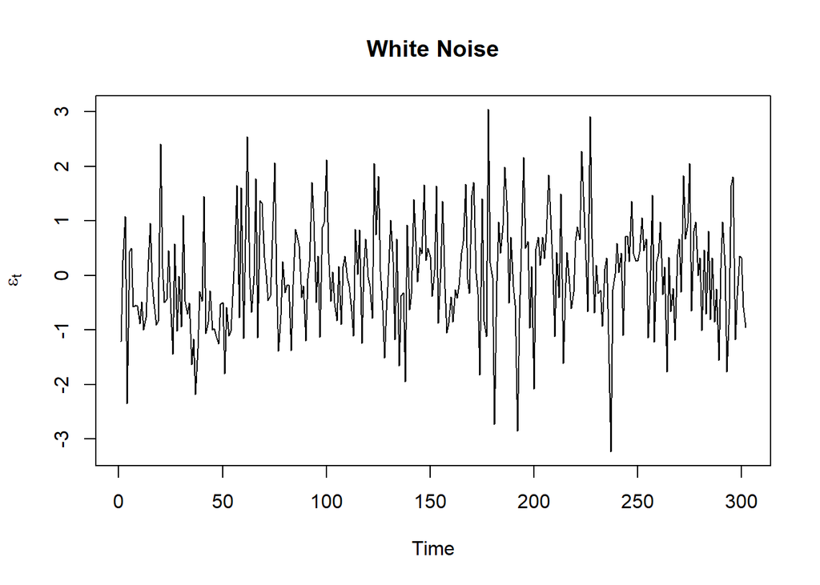

```r
# Langkah 1.1: Bangkitkan white noise
set.seed(1234)               # Supaya hasil bisa direplikasi
n <- 300                     # Banyak data
wn <- rnorm(n + 2, mean=0, sd=1)  # Tambah 2 data ekstra untuk lag

# Plot white noise
ts.plot(wn, main = "White Noise", ylab = expression(epsilon[t]))
```

Dari plot time series di atas terlihat bahwa data white noise berfluktuasi secara acak di sekitar rata-rata nol. Tidak ada pola tren yang jelas atau musiman (seasonality), dan variasinya relatif konstan dari waktu ke waktu.

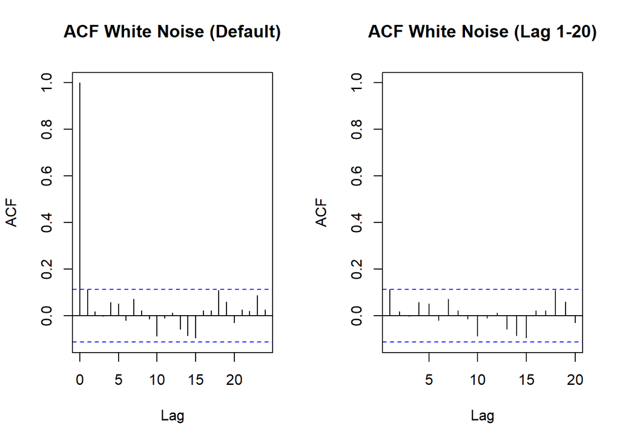

```r
# Langkah 1.2: Plot ACF white noise
par(mfrow = c(1, 2))

acf(wn, main = "ACF White Noise (Default)")
acf(wn, main = "ACF White Noise (Lag 1-20)", xlim = c(1, 20))
```

## Pembangkitan Proses MA(2)

Akan dicoba membangkitkan proses MA, yaitu MA(2) dengan $\theta{1} = 0.4$ dan $\theta{2} = 0.6$ sebanyak 300 observasi.

```r
# Langkah 2.1: Bangkitkan proses MA(2) secara manual
set.seed(1234)
n <- 300
wn <- rnorm(n + 2, mean=0, sd=1)  # white noise

theta1 <- 0.4
theta2 <- 0.6
```

Nilai-nilai selanjutnya dapat dicari melalui *loop*. Bentuk loop dapat dilihat dari rumus MA(2) yang hendak dibangkitkan:

$$y_t = e_t+0.4e_{t-1} + 0.6_{t-2}$$

```r
# Langkah 2.2: MA(2) manual (looping)
ma <- numeric(n)  # siapkan vektor kosong

for(i in 3:(n+2)){
  ma[i-2] <- wn[i] + theta1 * wn[i-1] + theta2 * wn[i-2]
}

ma
```

```
##   [1]  0.471173424 -1.745463687  0.141510314 -0.729712854 -0.114842790
##   [6] -0.472894305 -1.127948717 -1.443797742 -1.171879031 -1.723286222
##  [11] -1.461924092 -0.845074607  0.519525249  0.312187420  0.020572732
##  [16] -1.181770516 -1.508255550  1.534249256  0.598119283  1.012450498
##  [21] -0.556369299 -0.011041246 -0.774213194 -1.449939345 -0.420758391
##  [26] -1.662676381 -0.079747157 -1.556197355  0.718835126 -0.596243221
##  [31] -0.238298741 -1.070389923 -2.255260716 -2.120011486 -3.624543435
##  [36] -2.913580609 -2.138714925 -1.388210999  1.086560934 -0.768382742
##  [41] -0.413123964 -1.263954490 -1.619808057 -1.534624150 -2.091327966
##  [46] -2.276021753 -1.689013389 -1.457572736 -2.319068111 -1.602598402
##  [51] -2.425338748 -1.807763414 -1.233628102 -0.110845196  1.775654086
##  [56]  0.223607057  2.285258743 -0.979456751  1.157010823  2.116941328
##  [61]  1.378789117  0.845856907 -0.296314421  1.372262398 -0.432336811
##  [66]  1.978634754  1.193531021  1.688995021  0.939220832 -0.250827924
##  [71] -0.544575725  0.228395751  2.109671129  1.063681873 -0.209897795
```

[output cut: 45 more lines]

Selain menggunakan cara sebelumnya, pembangkitan proses MA(2) dapat dilakukan dengan fungsi `arima.sim()` sebagai berikut.

```r
# Langkah 2.3: MA(2) dengan arima.sim
set.seed(1234)
ma2 <- arima.sim(model = list(order = c(0, 0, 2), ma = c(0.4, 0.6)), n = 300)
ma2
```

```
## Time Series:
## Start = 1
## End = 300
## Frequency = 1
##   [1]  0.471173424 -1.745463687  0.141510314 -0.729712854 -0.114842790
##   [6] -0.472894305 -1.127948717 -1.443797742 -1.171879031 -1.723286222
##  [11] -1.461924092 -0.845074607  0.519525249  0.312187420  0.020572732
##  [16] -1.181770516 -1.508255550  1.534249256  0.598119283  1.012450498
##  [21] -0.556369299 -0.011041246 -0.774213194 -1.449939345 -0.420758391
##  [26] -1.662676381 -0.079747157 -1.556197355  0.718835126 -0.596243221
##  [31] -0.238298741 -1.070389923 -2.255260716 -2.120011486 -3.624543435
##  [36] -2.913580609 -2.138714925 -1.388210999  1.086560934 -0.768382742
##  [41] -0.413123964 -1.263954490 -1.619808057 -1.534624150 -2.091327966
##  [46] -2.276021753 -1.689013389 -1.457572736 -2.319068111 -1.602598402
##  [51] -2.425338748 -1.807763414 -1.233628102 -0.110845196  1.775654086
```

[output cut: 49 more lines]

### Plot Time Series

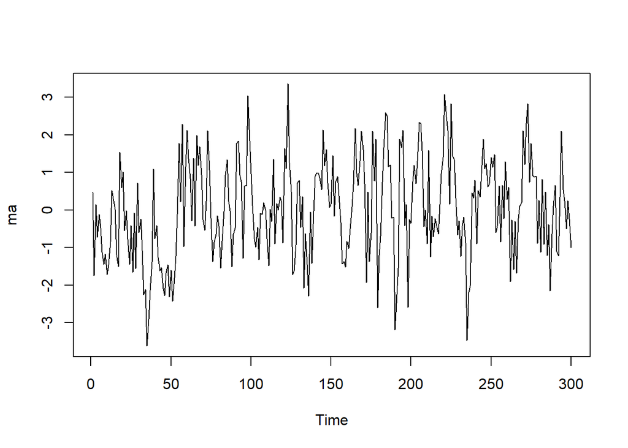

```r
ts.plot(ma)
```

Berdasarkan plot time series di atas, terlihat bahwa data hasil pembangkitan MA(2) berfluktuasi secara acak di sekitar rata-rata yang relatif konstan. Tidak terlihat adanya tren jangka panjang ataupun pola musiman. Varians data juga relatif stabil dari waktu ke waktu.Hal ini menunjukkan bahwa data hasil proses MA(2) bersifat *stasioner pada rataan*

### Plot ACF

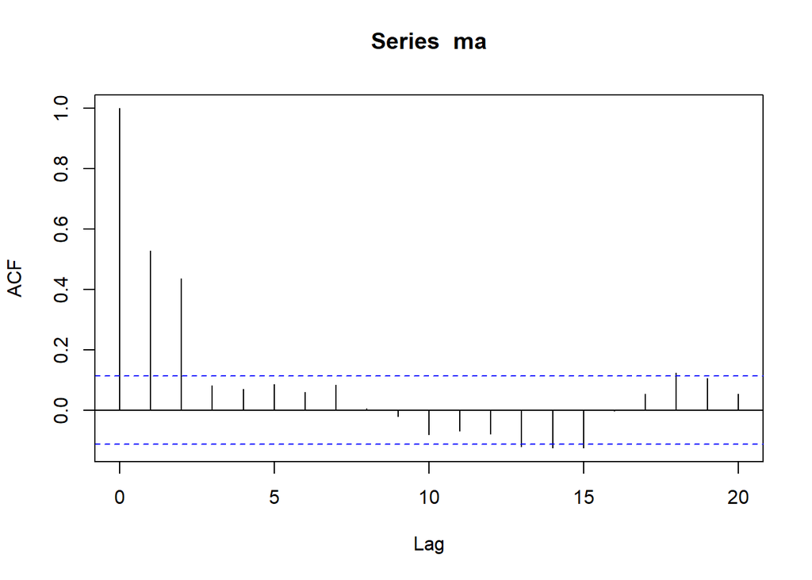

```r
acf(ma,lag.max = 20)
```

Berdasarkan plot ACF tersebut, terlihat bahwa plot ACF *cuts off* di lag kedua

### Plot PACF

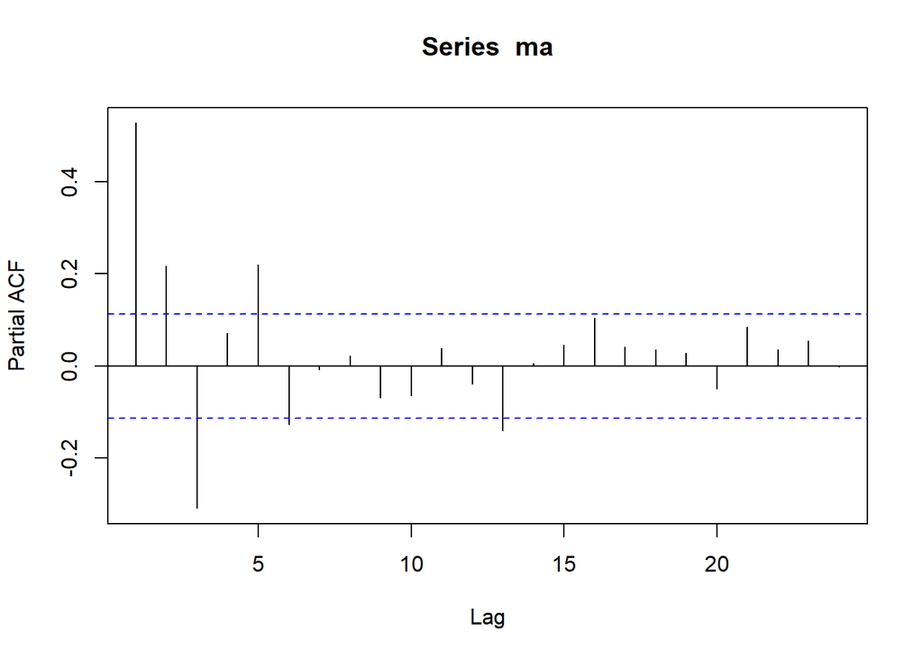

```r
pacf(ma)
```

Berdasarkan plot PACF di atas, terlihat bahwa nilai PACF tidak berhenti secara tiba-tiba pada lag tertentu, melainkan *cenderung menurun secara bertahap (tails off)*. Polanya berosilasi dan membentuk *gelombang sinus* yang semakin mengecil seiring bertambahnya lag.

### Plot EACF

```r
TSA::eacf(ma)
```

```
## AR/MA
##   0 1 2 3 4 5 6 7 8 9 10 11 12 13
## 0 x x o o o o o o o o o  o  x  x
## 1 x x x o o o o o o o o  o  o  o
## 2 x x x x o o o o o o o  o  o  o
## 3 x x x x o o o o o o o  o  o  o
## 4 x x x x o o o o o o o  o  o  o
## 5 x x o x x o x o o o o  o  o  o
## 6 o x o o x o o x o o o  o  o  o
## 7 x o x o x o o x o o o  o  o  o
```

Berdasarkan pola segitiga nol pada plot EACF, terlihat bahwa segitiga nol berada pada ordo AR(0) dan ordo MA(2)

### Scatterplot Antar Lag

#### Korelasi antara $Y_t$ dengan $Y_{t-1}$

```r
#Yt
yt_ma <- ma[-1]
yt_ma
```

```
##   [1] -1.745463687  0.141510314 -0.729712854 -0.114842790 -0.472894305
##   [6] -1.127948717 -1.443797742 -1.171879031 -1.723286222 -1.461924092
##  [11] -0.845074607  0.519525249  0.312187420  0.020572732 -1.181770516
##  [16] -1.508255550  1.534249256  0.598119283  1.012450498 -0.556369299
##  [21] -0.011041246 -0.774213194 -1.449939345 -0.420758391 -1.662676381
##  [26] -0.079747157 -1.556197355  0.718835126 -0.596243221 -0.238298741
##  [31] -1.070389923 -2.255260716 -2.120011486 -3.624543435 -2.913580609
##  [36] -2.138714925 -1.388210999  1.086560934 -0.768382742 -0.413123964
##  [41] -1.263954490 -1.619808057 -1.534624150 -2.091327966 -2.276021753
##  [46] -1.689013389 -1.457572736 -2.319068111 -1.602598402 -2.425338748
##  [51] -1.807763414 -1.233628102 -0.110845196  1.775654086  0.223607057
##  [56]  2.285258743 -0.979456751  1.157010823  2.116941328  1.378789117
##  [61]  0.845856907 -0.296314421  1.372262398 -0.432336811  1.978634754
##  [66]  1.193531021  1.688995021  0.939220832 -0.250827924 -0.544575725
##  [71]  0.228395751  2.109671129  1.063681873 -0.209897795 -1.371901203
```

[output cut: 45 more lines]

```r
#Yt-1
yt_1_ma <- ma[-300]
yt_1_ma
```

```
##   [1]  0.471173424 -1.745463687  0.141510314 -0.729712854 -0.114842790
##   [6] -0.472894305 -1.127948717 -1.443797742 -1.171879031 -1.723286222
##  [11] -1.461924092 -0.845074607  0.519525249  0.312187420  0.020572732
##  [16] -1.181770516 -1.508255550  1.534249256  0.598119283  1.012450498
##  [21] -0.556369299 -0.011041246 -0.774213194 -1.449939345 -0.420758391
##  [26] -1.662676381 -0.079747157 -1.556197355  0.718835126 -0.596243221
##  [31] -0.238298741 -1.070389923 -2.255260716 -2.120011486 -3.624543435
##  [36] -2.913580609 -2.138714925 -1.388210999  1.086560934 -0.768382742
##  [41] -0.413123964 -1.263954490 -1.619808057 -1.534624150 -2.091327966
##  [46] -2.276021753 -1.689013389 -1.457572736 -2.319068111 -1.602598402
##  [51] -2.425338748 -1.807763414 -1.233628102 -0.110845196  1.775654086
##  [56]  0.223607057  2.285258743 -0.979456751  1.157010823  2.116941328
##  [61]  1.378789117  0.845856907 -0.296314421  1.372262398 -0.432336811
##  [66]  1.978634754  1.193531021  1.688995021  0.939220832 -0.250827924
##  [71] -0.544575725  0.228395751  2.109671129  1.063681873 -0.209897795
```

[output cut: 45 more lines]

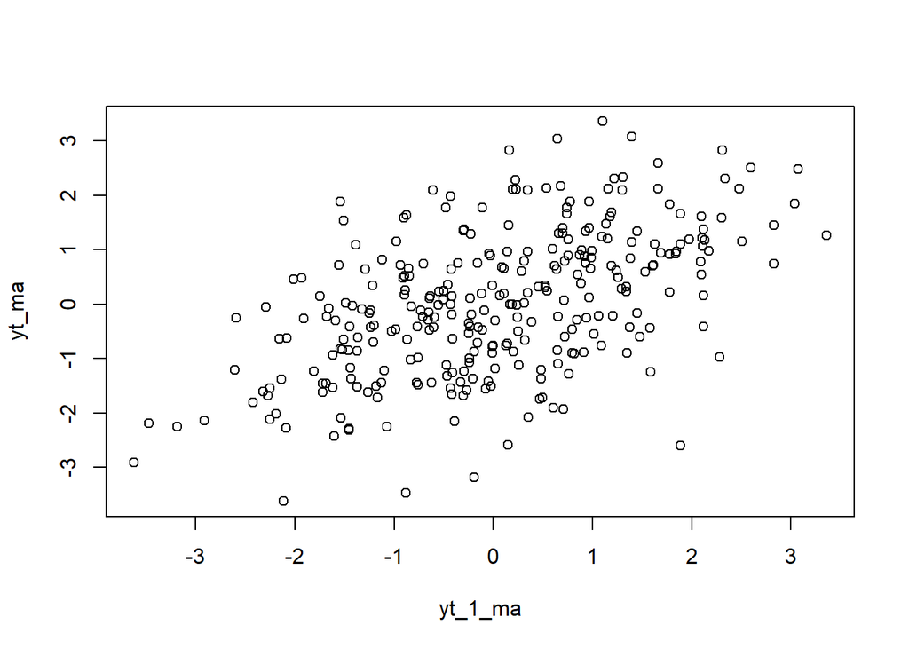

```r
plot(y=yt_ma,x=yt_1_ma)
```

Berdasarkan scatterplot tersebut, terlihat bahwa terdapat hubungan positif antara $Y_t$ dengan $Y_{t-1}$.

```r
cor(yt_ma,yt_1_ma)
```

```
## [1] 0.5285939
```

Korelasi antara $Y_t$ dengan $Y_{t-1}$ dari hasil simulasi mendekati perhitungan teoritis yaitu:
$$\rho_1 = \frac{\theta_1 + \theta_1\theta_2}{1+\theta_1^2+\theta_2^2}
= \frac{0.4 + 0.4 \times 0.6}{1+0.4^2+0.6^2}
= \frac{0.64}{1.52}
\approx 0.421$$

Hasil simulasi R: $\hat{\rho}_1 \approx 0.529$.  
Interpretasi nilai sample sedikit lebih besar karena efek variasi sampel (n=300) dan realisasi acak.

#### Korelasi antara $Y_t$ dengan $Y_{t-2}$

```r
#Yt (buang elemen 1 dan 2 → mulai dari Y3)
yt_ma2 <- ma[-c(1,2)]
yt_ma2
```

```
##   [1]  0.141510314 -0.729712854 -0.114842790 -0.472894305 -1.127948717
##   [6] -1.443797742 -1.171879031 -1.723286222 -1.461924092 -0.845074607
##  [11]  0.519525249  0.312187420  0.020572732 -1.181770516 -1.508255550
##  [16]  1.534249256  0.598119283  1.012450498 -0.556369299 -0.011041246
##  [21] -0.774213194 -1.449939345 -0.420758391 -1.662676381 -0.079747157
##  [26] -1.556197355  0.718835126 -0.596243221 -0.238298741 -1.070389923
##  [31] -2.255260716 -2.120011486 -3.624543435 -2.913580609 -2.138714925
##  [36] -1.388210999  1.086560934 -0.768382742 -0.413123964 -1.263954490
##  [41] -1.619808057 -1.534624150 -2.091327966 -2.276021753 -1.689013389
##  [46] -1.457572736 -2.319068111 -1.602598402 -2.425338748 -1.807763414
##  [51] -1.233628102 -0.110845196  1.775654086  0.223607057  2.285258743
##  [56] -0.979456751  1.157010823  2.116941328  1.378789117  0.845856907
##  [61] -0.296314421  1.372262398 -0.432336811  1.978634754  1.193531021
##  [66]  1.688995021  0.939220832 -0.250827924 -0.544575725  0.228395751
##  [71]  2.109671129  1.063681873 -0.209897795 -1.371901203 -0.865591517
```

[output cut: 45 more lines]

```r
#Yt-2 (buang elemen 299 dan 300 → sampai Y298)
yt_2_ma <- ma[-c(299,300)]
yt_2_ma
```

```
##   [1]  0.471173424 -1.745463687  0.141510314 -0.729712854 -0.114842790
##   [6] -0.472894305 -1.127948717 -1.443797742 -1.171879031 -1.723286222
##  [11] -1.461924092 -0.845074607  0.519525249  0.312187420  0.020572732
##  [16] -1.181770516 -1.508255550  1.534249256  0.598119283  1.012450498
##  [21] -0.556369299 -0.011041246 -0.774213194 -1.449939345 -0.420758391
##  [26] -1.662676381 -0.079747157 -1.556197355  0.718835126 -0.596243221
##  [31] -0.238298741 -1.070389923 -2.255260716 -2.120011486 -3.624543435
##  [36] -2.913580609 -2.138714925 -1.388210999  1.086560934 -0.768382742
##  [41] -0.413123964 -1.263954490 -1.619808057 -1.534624150 -2.091327966
##  [46] -2.276021753 -1.689013389 -1.457572736 -2.319068111 -1.602598402
##  [51] -2.425338748 -1.807763414 -1.233628102 -0.110845196  1.775654086
##  [56]  0.223607057  2.285258743 -0.979456751  1.157010823  2.116941328
##  [61]  1.378789117  0.845856907 -0.296314421  1.372262398 -0.432336811
##  [66]  1.978634754  1.193531021  1.688995021  0.939220832 -0.250827924
##  [71] -0.544575725  0.228395751  2.109671129  1.063681873 -0.209897795
```

[output cut: 45 more lines]

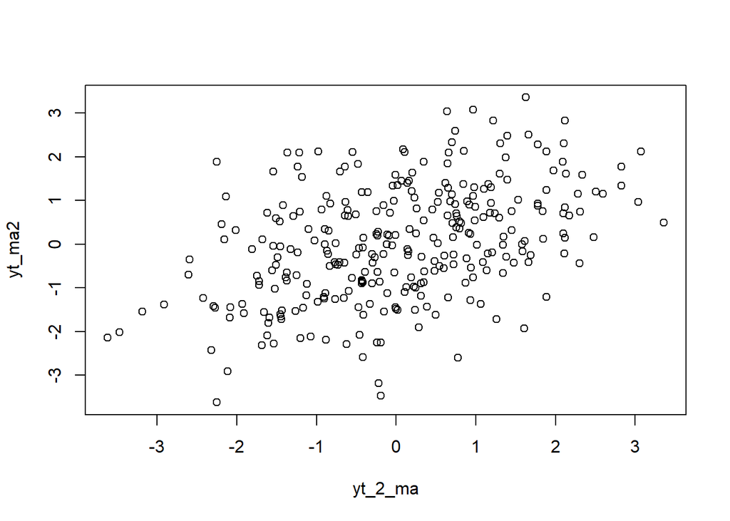

```r
plot(y=yt_ma2,x=yt_2_ma)
```

```r
cor(yt_ma2,yt_2_ma)
```

```
## [1] 0.4372298
```

Berdasarkan teoritis:
$$\rho_2 = \frac{\theta_2}{1+\theta_1^2+\theta_2^2}
= \frac{0.6}{1.52}
\approx 0.395$$

#### Korelasi antara $Y_t$ dengan $Y_{t-3}$

```r
#Yt (buang elemen 1, 2, 3 → mulai dari Y4)
yt_ma3 <- ma[-c(1,2,3)]
yt_ma3
```

```
##   [1] -0.729712854 -0.114842790 -0.472894305 -1.127948717 -1.443797742
##   [6] -1.171879031 -1.723286222 -1.461924092 -0.845074607  0.519525249
##  [11]  0.312187420  0.020572732 -1.181770516 -1.508255550  1.534249256
##  [16]  0.598119283  1.012450498 -0.556369299 -0.011041246 -0.774213194
##  [21] -1.449939345 -0.420758391 -1.662676381 -0.079747157 -1.556197355
##  [26]  0.718835126 -0.596243221 -0.238298741 -1.070389923 -2.255260716
##  [31] -2.120011486 -3.624543435 -2.913580609 -2.138714925 -1.388210999
##  [36]  1.086560934 -0.768382742 -0.413123964 -1.263954490 -1.619808057
##  [41] -1.534624150 -2.091327966 -2.276021753 -1.689013389 -1.457572736
##  [46] -2.319068111 -1.602598402 -2.425338748 -1.807763414 -1.233628102
##  [51] -0.110845196  1.775654086  0.223607057  2.285258743 -0.979456751
##  [56]  1.157010823  2.116941328  1.378789117  0.845856907 -0.296314421
##  [61]  1.372262398 -0.432336811  1.978634754  1.193531021  1.688995021
##  [66]  0.939220832 -0.250827924 -0.544575725  0.228395751  2.109671129
##  [71]  1.063681873 -0.209897795 -1.371901203 -0.865591517 -0.647903476
```

[output cut: 45 more lines]

```r
#Yt-3 (buang elemen 298, 299, 300 → sampai Y297)
yt_3_ma <- ma[-c(298,299,300)]
yt_3_ma
```

```
##   [1]  0.471173424 -1.745463687  0.141510314 -0.729712854 -0.114842790
##   [6] -0.472894305 -1.127948717 -1.443797742 -1.171879031 -1.723286222
##  [11] -1.461924092 -0.845074607  0.519525249  0.312187420  0.020572732
##  [16] -1.181770516 -1.508255550  1.534249256  0.598119283  1.012450498
##  [21] -0.556369299 -0.011041246 -0.774213194 -1.449939345 -0.420758391
##  [26] -1.662676381 -0.079747157 -1.556197355  0.718835126 -0.596243221
##  [31] -0.238298741 -1.070389923 -2.255260716 -2.120011486 -3.624543435
##  [36] -2.913580609 -2.138714925 -1.388210999  1.086560934 -0.768382742
##  [41] -0.413123964 -1.263954490 -1.619808057 -1.534624150 -2.091327966
##  [46] -2.276021753 -1.689013389 -1.457572736 -2.319068111 -1.602598402
##  [51] -2.425338748 -1.807763414 -1.233628102 -0.110845196  1.775654086
##  [56]  0.223607057  2.285258743 -0.979456751  1.157010823  2.116941328
##  [61]  1.378789117  0.845856907 -0.296314421  1.372262398 -0.432336811
##  [66]  1.978634754  1.193531021  1.688995021  0.939220832 -0.250827924
##  [71] -0.544575725  0.228395751  2.109671129  1.063681873 -0.209897795
```

[output cut: 45 more lines]

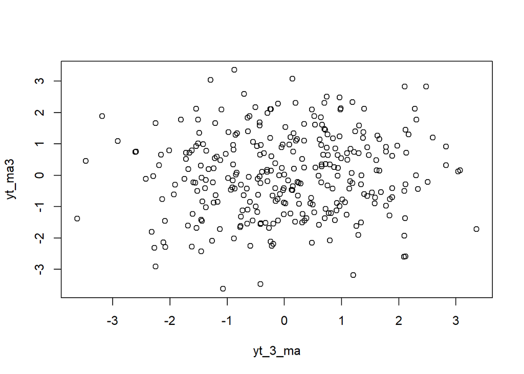

```r
plot(y=yt_ma3,x=yt_3_ma)
```

```r
cor(yt_ma3,yt_3_ma)
```

```
## [1] 0.08239345
```

$$\rho_3^{(teoritis)} = 0$$

Hasil simulasi R: $\hat{\rho}_3 \approx 0.082$.  
Interpretasi secara teori harus nol, tetapi pada sampel terbatas muncul penyimpangan kecil karena variasi acak.

### Kesimpulan MA(2)

Untuk model MA(2) dengan $\theta_1 = 0.4$ dan $\theta_2 = 0.6$, hasil perhitungan teoritis memberikan nilai:

- $\rho_1 = \dfrac{\theta_1 + \theta_1\theta_2}{1 + \theta_1^2 + \theta_2^2} = 0.421$
- $\rho_2 = \dfrac{\theta_2}{1 + \theta_1^2 + \theta_2^2} = 0.395$
- $\rho_k = 0 \quad \text{untuk } k > 2$

Sedangkan dari hasil simulasi (dengan $n=300$), diperoleh nilai autokorelasi sampel:

- $\hat{\rho}_1 \approx 0.529$
- $\hat{\rho}_2 \approx 0.437$
- $\hat{\rho}_3 \approx 0.082$

Terlihat bahwa nilai sampel sedikit berbeda dengan nilai teoritis karena adanya variasi sampel (ukuran terbatas dan sifat acak simulasi).  
Namun pola yang muncul konsisten dengan karakteristik MA(2), yaitu autokorelasi *cut off* setelah lag ke-2.

## Pembangkitan Proses AR(2)

```r
#Langkah 2,1
set.seed(1234)
```

Nilai-nilai selanjutnya dapat dicari melalui *loop*. Bentuk loop dapat dilihat dari rumus AR(2) yang hendak dibangkitkan:

$$Y_t =
e_t+0.5Y_{t-1}+0.2Y_{t-2}$$

```r
# Langkah 2.2: Looping AR(2)

n <- length(wn)
n
```

```
## [1] 302
```

```r
ar2 <- c(1:n)

for (i in 3:n) {
  ar2[i] <- wn[i] + 0.5*ar2[i-1] + 0.2*ar2[i-2]
}

ar2
```

```
##   [1]  1.000000000  2.000000000  2.284441177 -0.803477114  0.484274367
##   [6]  0.587497653 -0.184136260 -0.521200455 -0.861879479 -1.425217660
##  [11] -1.362177425 -1.964518689 -2.030948724 -1.343919283 -0.118655327
##  [16] -0.438397015 -0.753939079 -1.375844359 -1.675881675  1.302725469
##  [21]  0.450274620 -0.005003493 -0.352994695  0.282091395 -0.623273488
##  [26] -1.703423376 -0.401610665 -1.565145730 -0.878033298 -1.687994396
##  [31]  0.082693688 -0.771845114 -1.078823857 -1.195039012 -2.442377746
##  [36] -2.627815938 -3.982423167 -3.857767963 -3.019662474 -2.747282370
##  [41] -0.528077414 -1.882137905 -1.902049069 -1.608075117 -2.178787449
##  [46] -2.379523066 -2.732837215 -3.094309106 -2.617550115 -2.424486836
##  [51] -3.541784698 -2.837865641 -3.236179384 -3.200624830 -2.409857815
##  [56] -1.281998055  0.524846882 -0.767329594  1.327214208 -0.647667362
##  [61]  0.598197625  2.718556411  1.444157341  0.596156373  0.579304899
##  [66]  2.185968172  0.070237329  1.840139478  2.263681996  1.836341691
##  [71]  1.377800083  0.600699641  0.209385904  0.873119448  2.548707766
```

[output cut: 46 more lines]

Selain menggunakan cara di atas, pembangkitan proses AR dapat dilakukan dengan fungsi `arima.sim()` sebagai berikut.

```r
#Langkah 2.3: Pembangkitan dengan `arima.sim()`
set.seed(1234)
ar2_sim <- arima.sim(list(order=c(2,0,0), ar=c(0.5, 0.2)), n=300)
ar2_sim
```

```
## Time Series:
## Start = 1
## End = 300
## Frequency = 1
##   [1] -1.7066325607 -0.4040571790 -1.5670108246 -0.8794551485 -1.6890783403
##   [6]  0.0818673463 -0.7724750738 -1.0793041051 -1.1954051279 -2.4426568541
##  [11] -2.6280287147 -3.9825853771 -3.8578916236 -3.0197567460 -2.7473542381
##  [16] -0.5281322030 -1.8821796728 -1.9020809107 -1.6080993919 -2.1788059544
##  [21] -2.3795371734 -2.7328479702 -3.0943173054 -2.6175563658 -2.4244916012
##  [26] -3.5417883306 -2.8378684102 -3.2361814957 -3.2006264394 -2.4098590424
##  [31] -1.2819989901  0.5248461693 -0.7673301373  1.3272137941 -0.6476676781
##  [36]  0.5981973841  2.7185562271  1.4441572006  0.5961562661  0.5793048174
##  [41]  2.1859681101  0.0702372818  1.8401394423  2.2636819683  1.8363416698
##  [46]  1.3778000670  0.6006996293  0.2093858952  0.8731194410  2.5487077608
##  [51]  1.2955793561 -0.2331697165 -0.5810507641 -0.0788975632 -0.4727180494
```

[output cut: 49 more lines]

## Karakteristik AR(2)

### Plot Time Series

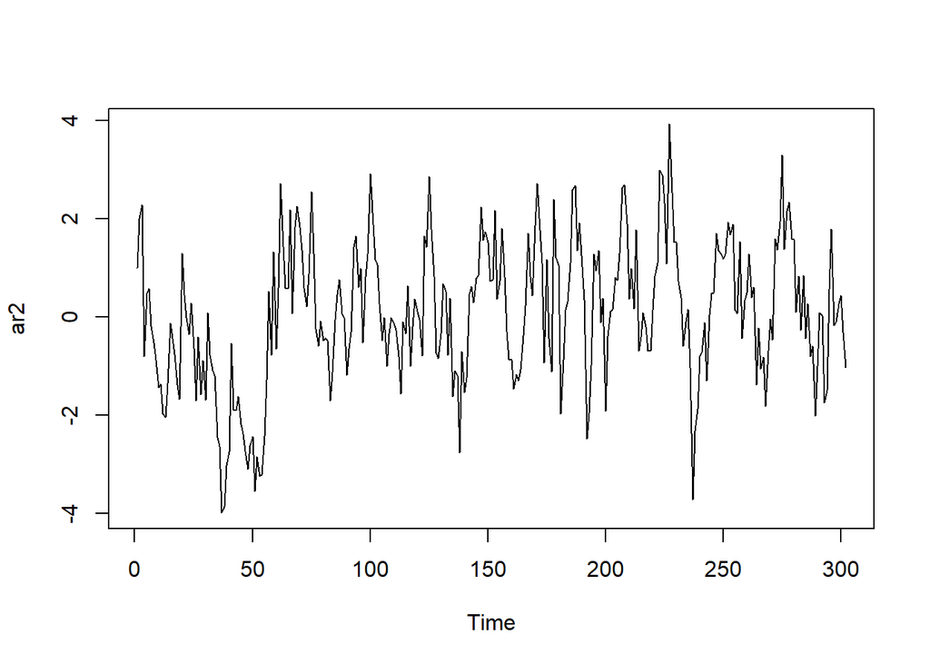

```r
ts.plot(ar2)
```

Berdasarkan plot time series tersebut terlihat bahwa data cenderung stasioner pada rataan

### Plot ACF

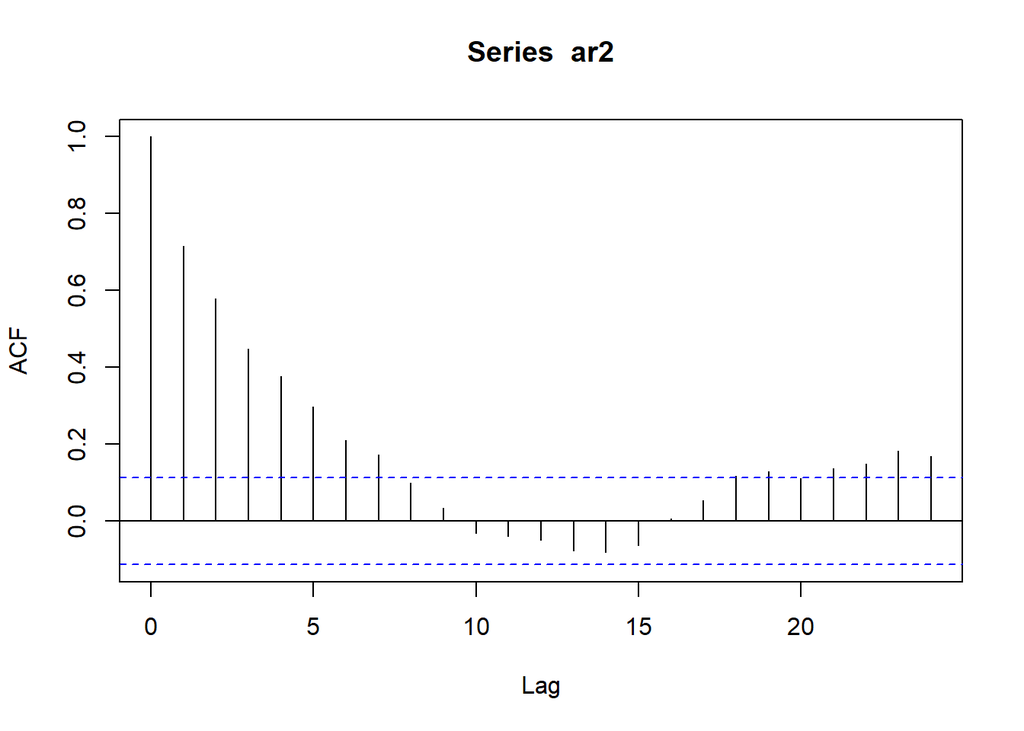

```r
acf(ar2)
```

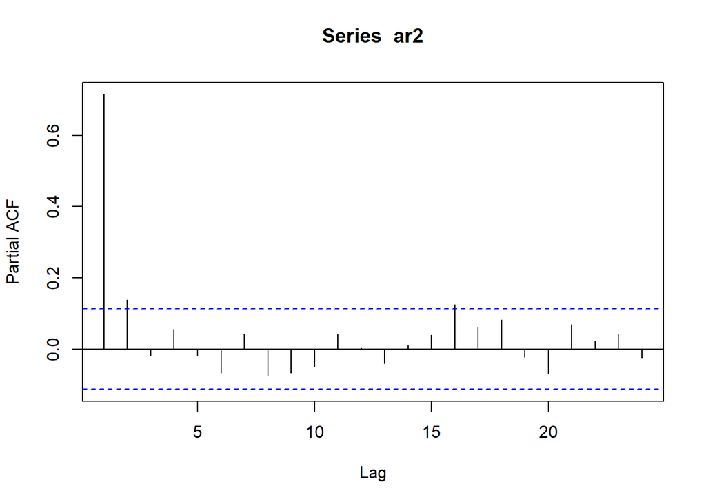

```r
pacf(ar2)
```

Berdasarkan plot PACF tersebut, terlihat bahwa plot PACF *cuts off* pada lag kedua, sejalan dengan teori yang ada

### Plot EACF

```r
TSA::eacf(ar2)
```

```
## AR/MA
##   0 1 2 3 4 5 6 7 8 9 10 11 12 13
## 0 x x x x x x x o o o o  o  o  o
## 1 x o o o o o o o o o o  o  o  o
## 2 x o o o o o o o o o o  o  o  o
## 3 x x o o o o o o o o o  o  o  o
## 4 x x o o o o o o o o o  o  o  o
## 5 x x x x o o x o o o o  o  o  o
## 6 x x x o o o x o o o o  o  o  o
## 7 x x x o x x o o o o o  o  o  o
```

### Scatterplot Antar Lag

#### Korelasi antara $Y_t$ dengan $Y_{t-1}$

```r
# Yt (dari observasi ke-2 sampai akhir)
yt_ar <- ar2[2:length(ar2)]
yt_ar
```

```
##   [1]  2.000000000  2.284441177 -0.803477114  0.484274367  0.587497653
##   [6] -0.184136260 -0.521200455 -0.861879479 -1.425217660 -1.362177425
##  [11] -1.964518689 -2.030948724 -1.343919283 -0.118655327 -0.438397015
##  [16] -0.753939079 -1.375844359 -1.675881675  1.302725469  0.450274620
##  [21] -0.005003493 -0.352994695  0.282091395 -0.623273488 -1.703423376
##  [26] -0.401610665 -1.565145730 -0.878033298 -1.687994396  0.082693688
##  [31] -0.771845114 -1.078823857 -1.195039012 -2.442377746 -2.627815938
##  [36] -3.982423167 -3.857767963 -3.019662474 -2.747282370 -0.528077414
##  [41] -1.882137905 -1.902049069 -1.608075117 -2.178787449 -2.379523066
##  [46] -2.732837215 -3.094309106 -2.617550115 -2.424486836 -3.541784698
##  [51] -2.837865641 -3.236179384 -3.200624830 -2.409857815 -1.281998055
##  [56]  0.524846882 -0.767329594  1.327214208 -0.647667362  0.598197625
##  [61]  2.718556411  1.444157341  0.596156373  0.579304899  2.185968172
##  [66]  0.070237329  1.840139478  2.263681996  1.836341691  1.377800083
##  [71]  0.600699641  0.209385904  0.873119448  2.548707766  1.295579360
```

[output cut: 46 more lines]

```r
# Yt-1 (dari observasi ke-1 sampai n-1)
yt_1_ar <- ar2[1:(length(ar2)-1)]
yt_1_ar
```

```
##   [1]  1.000000000  2.000000000  2.284441177 -0.803477114  0.484274367
##   [6]  0.587497653 -0.184136260 -0.521200455 -0.861879479 -1.425217660
##  [11] -1.362177425 -1.964518689 -2.030948724 -1.343919283 -0.118655327
##  [16] -0.438397015 -0.753939079 -1.375844359 -1.675881675  1.302725469
##  [21]  0.450274620 -0.005003493 -0.352994695  0.282091395 -0.623273488
##  [26] -1.703423376 -0.401610665 -1.565145730 -0.878033298 -1.687994396
##  [31]  0.082693688 -0.771845114 -1.078823857 -1.195039012 -2.442377746
##  [36] -2.627815938 -3.982423167 -3.857767963 -3.019662474 -2.747282370
##  [41] -0.528077414 -1.882137905 -1.902049069 -1.608075117 -2.178787449
##  [46] -2.379523066 -2.732837215 -3.094309106 -2.617550115 -2.424486836
##  [51] -3.541784698 -2.837865641 -3.236179384 -3.200624830 -2.409857815
##  [56] -1.281998055  0.524846882 -0.767329594  1.327214208 -0.647667362
##  [61]  0.598197625  2.718556411  1.444157341  0.596156373  0.579304899
##  [66]  2.185968172  0.070237329  1.840139478  2.263681996  1.836341691
##  [71]  1.377800083  0.600699641  0.209385904  0.873119448  2.548707766
```

[output cut: 46 more lines]

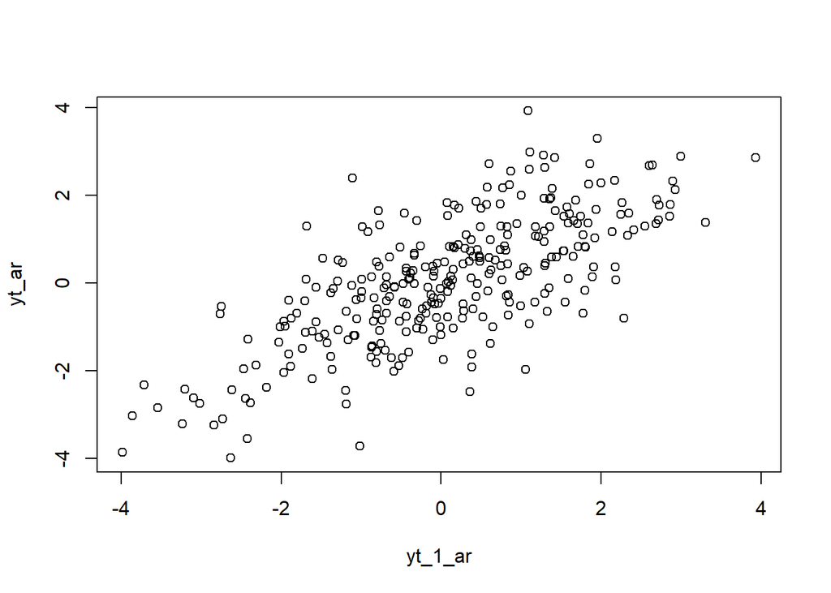

```r
plot(y=yt_ar,x=yt_1_ar)
```

Berdasarkan scatterplot tersebut, terlihat bahwa terdapat hubungan positif antara $Y_t$ dengan $Y_{t-1}$. Hal ini sesuai dengan teori yang ada

```r
cor(yt_ar,yt_1_ar)
```

```
## [1] 0.7168414
```

```r
#Perhitungan secara teori
phi1 <- 0.5
phi2 <- 0.2

# rho1
rho1 <- phi1 / (1 - phi2)
rho1
```

```
## [1] 0.625
```

#### Korelasi antara $Y_t$ dengan $Y_{t-2}$

```r
#Yt
# Yt dan Yt-2
yt_ar2   <- ar2[3:length(ar2)]
yt_2_ar <- ar2[1:(length(ar2)-2)]

# Print semua nilai
yt_ar2
```

```
##   [1]  2.284441177 -0.803477114  0.484274367  0.587497653 -0.184136260
##   [6] -0.521200455 -0.861879479 -1.425217660 -1.362177425 -1.964518689
##  [11] -2.030948724 -1.343919283 -0.118655327 -0.438397015 -0.753939079
##  [16] -1.375844359 -1.675881675  1.302725469  0.450274620 -0.005003493
##  [21] -0.352994695  0.282091395 -0.623273488 -1.703423376 -0.401610665
##  [26] -1.565145730 -0.878033298 -1.687994396  0.082693688 -0.771845114
##  [31] -1.078823857 -1.195039012 -2.442377746 -2.627815938 -3.982423167
##  [36] -3.857767963 -3.019662474 -2.747282370 -0.528077414 -1.882137905
##  [41] -1.902049069 -1.608075117 -2.178787449 -2.379523066 -2.732837215
##  [46] -3.094309106 -2.617550115 -2.424486836 -3.541784698 -2.837865641
##  [51] -3.236179384 -3.200624830 -2.409857815 -1.281998055  0.524846882
##  [56] -0.767329594  1.327214208 -0.647667362  0.598197625  2.718556411
##  [61]  1.444157341  0.596156373  0.579304899  2.185968172  0.070237329
##  [66]  1.840139478  2.263681996  1.836341691  1.377800083  0.600699641
##  [71]  0.209385904  0.873119448  2.548707766  1.295579360 -0.233169713
```

[output cut: 45 more lines]

```r
yt_2_ar
```

```
##   [1]  1.000000000  2.000000000  2.284441177 -0.803477114  0.484274367
##   [6]  0.587497653 -0.184136260 -0.521200455 -0.861879479 -1.425217660
##  [11] -1.362177425 -1.964518689 -2.030948724 -1.343919283 -0.118655327
##  [16] -0.438397015 -0.753939079 -1.375844359 -1.675881675  1.302725469
##  [21]  0.450274620 -0.005003493 -0.352994695  0.282091395 -0.623273488
##  [26] -1.703423376 -0.401610665 -1.565145730 -0.878033298 -1.687994396
##  [31]  0.082693688 -0.771845114 -1.078823857 -1.195039012 -2.442377746
##  [36] -2.627815938 -3.982423167 -3.857767963 -3.019662474 -2.747282370
##  [41] -0.528077414 -1.882137905 -1.902049069 -1.608075117 -2.178787449
##  [46] -2.379523066 -2.732837215 -3.094309106 -2.617550115 -2.424486836
##  [51] -3.541784698 -2.837865641 -3.236179384 -3.200624830 -2.409857815
##  [56] -1.281998055  0.524846882 -0.767329594  1.327214208 -0.647667362
##  [61]  0.598197625  2.718556411  1.444157341  0.596156373  0.579304899
##  [66]  2.185968172  0.070237329  1.840139478  2.263681996  1.836341691
##  [71]  1.377800083  0.600699641  0.209385904  0.873119448  2.548707766
```

[output cut: 45 more lines]

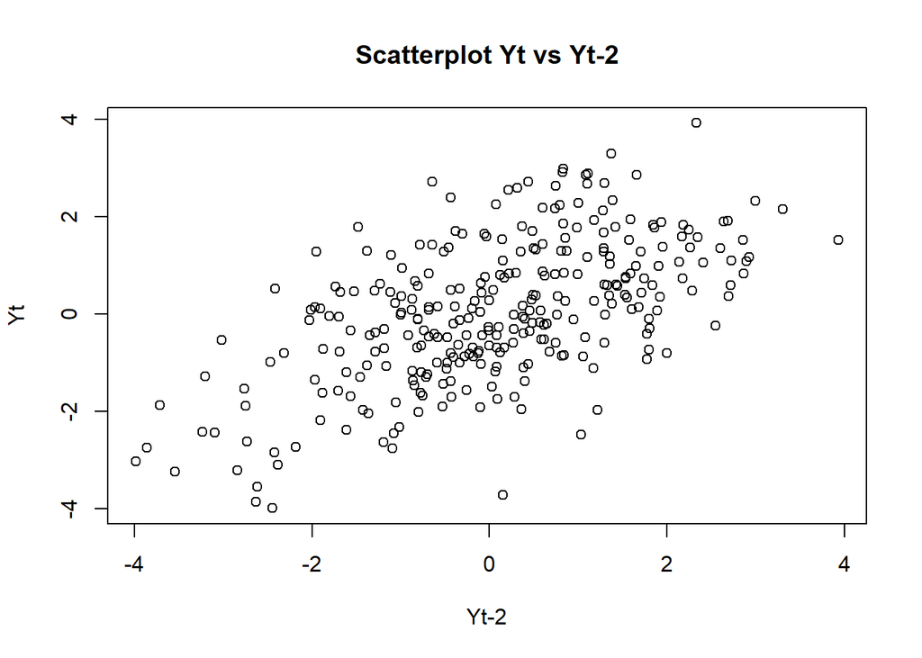

```r
# Scatterplot
plot(y = yt_ar2, x = yt_2_ar, main = "Scatterplot Yt vs Yt-2",
     xlab = "Yt-2", ylab = "Yt")
```

Berdasarkan scatterplot tersebut, terlihat bahwa terdapat hubungan positif antara $Y_t$ dengan $Y_{t-2}$. Hal ini sesuai dengan teori yang ada

```r
cor(yt_ar2,yt_2_ar)
```

```
## [1] 0.5822235
```

```r
phi1 <- 0.5
phi2 <- 0.2

# rho2
rho2 <- phi1 * rho1 + phi2
rho2
```

```
## [1] 0.5125
```

#### Korelasi antara $Y_t$ dengan $Y_{t-3}$

```r
# Yt dan Yt-3
yt_ar3   <- ar2[4:length(ar2)]
yt_3_ar <- ar2[1:(length(ar2)-3)]

# Print semua nilai
yt_ar3
```

```
##   [1] -0.803477114  0.484274367  0.587497653 -0.184136260 -0.521200455
##   [6] -0.861879479 -1.425217660 -1.362177425 -1.964518689 -2.030948724
##  [11] -1.343919283 -0.118655327 -0.438397015 -0.753939079 -1.375844359
##  [16] -1.675881675  1.302725469  0.450274620 -0.005003493 -0.352994695
##  [21]  0.282091395 -0.623273488 -1.703423376 -0.401610665 -1.565145730
##  [26] -0.878033298 -1.687994396  0.082693688 -0.771845114 -1.078823857
##  [31] -1.195039012 -2.442377746 -2.627815938 -3.982423167 -3.857767963
##  [36] -3.019662474 -2.747282370 -0.528077414 -1.882137905 -1.902049069
##  [41] -1.608075117 -2.178787449 -2.379523066 -2.732837215 -3.094309106
##  [46] -2.617550115 -2.424486836 -3.541784698 -2.837865641 -3.236179384
##  [51] -3.200624830 -2.409857815 -1.281998055  0.524846882 -0.767329594
##  [56]  1.327214208 -0.647667362  0.598197625  2.718556411  1.444157341
##  [61]  0.596156373  0.579304899  2.185968172  0.070237329  1.840139478
##  [66]  2.263681996  1.836341691  1.377800083  0.600699641  0.209385904
##  [71]  0.873119448  2.548707766  1.295579360 -0.233169713 -0.581050762
```

[output cut: 45 more lines]

```r
yt_3_ar
```

```
##   [1]  1.000000000  2.000000000  2.284441177 -0.803477114  0.484274367
##   [6]  0.587497653 -0.184136260 -0.521200455 -0.861879479 -1.425217660
##  [11] -1.362177425 -1.964518689 -2.030948724 -1.343919283 -0.118655327
##  [16] -0.438397015 -0.753939079 -1.375844359 -1.675881675  1.302725469
##  [21]  0.450274620 -0.005003493 -0.352994695  0.282091395 -0.623273488
##  [26] -1.703423376 -0.401610665 -1.565145730 -0.878033298 -1.687994396
##  [31]  0.082693688 -0.771845114 -1.078823857 -1.195039012 -2.442377746
##  [36] -2.627815938 -3.982423167 -3.857767963 -3.019662474 -2.747282370
##  [41] -0.528077414 -1.882137905 -1.902049069 -1.608075117 -2.178787449
##  [46] -2.379523066 -2.732837215 -3.094309106 -2.617550115 -2.424486836
##  [51] -3.541784698 -2.837865641 -3.236179384 -3.200624830 -2.409857815
##  [56] -1.281998055  0.524846882 -0.767329594  1.327214208 -0.647667362
##  [61]  0.598197625  2.718556411  1.444157341  0.596156373  0.579304899
##  [66]  2.185968172  0.070237329  1.840139478  2.263681996  1.836341691
##  [71]  1.377800083  0.600699641  0.209385904  0.873119448  2.548707766
```

[output cut: 45 more lines]

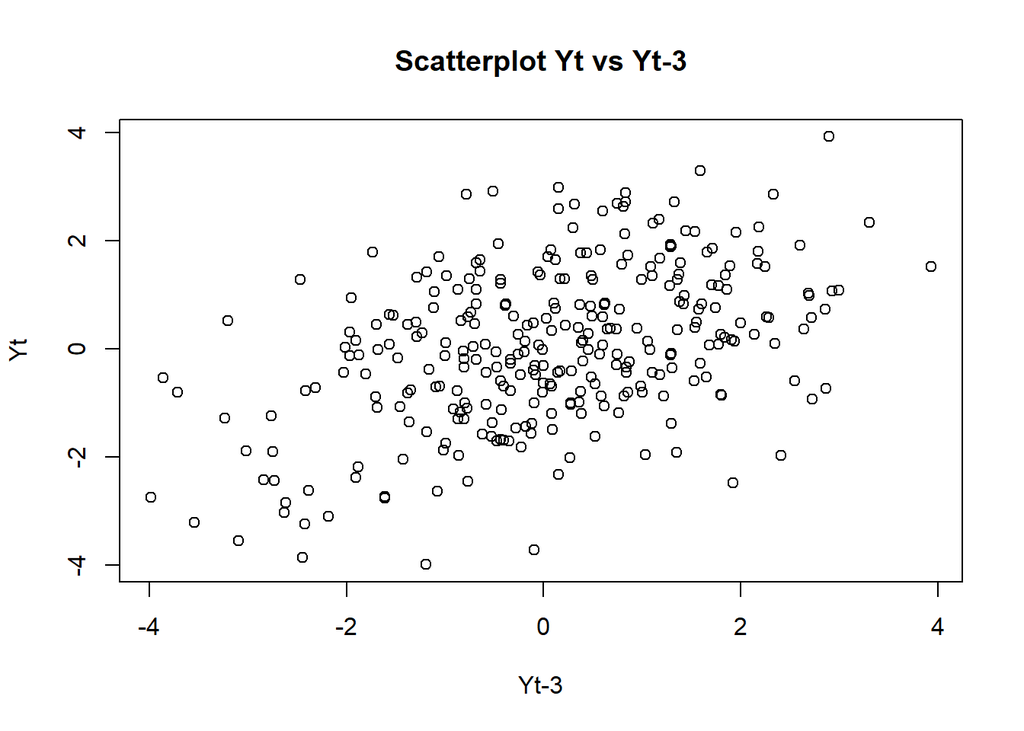

```r
# Scatterplot
plot(y = yt_ar3, x = yt_3_ar, main = "Scatterplot Yt vs Yt-3",
     xlab = "Yt-3", ylab = "Yt")
```

```r
# Korelasi
cor(yt_ar3, yt_3_ar)
```

```
## [1] 0.4514806
```

```r
phi1 <- 0.5
phi2 <- 0.2

# rho3
rho3 <- phi1 * rho2 + phi2 * rho1
rho3
```

```
## [1] 0.38125
```

### Kesimpulan AR (2)

Dari hasil simulasi, nilai autokorelasi sampel pada lag 1, 2, dan 3 berturut-turut adalah **0.7168**, **0.5822**, dan **0.4515**.  
Sementara berdasarkan perhitungan teoritis untuk model AR(2) dengan $\phi_1 = 0.5$ dan $\phi_2 = 0.2$, diperoleh nilai:

- $\rho_1 = 0.625$
- $\rho_2 = 0.5125$
- $\rho_3 = 0.3813$

Walaupun terdapat perbedaan antara nilai empiris (sampel) dan teoritis (populasi), pola yang terbentuk tetap konsisten, yaitu nilai autokorelasi menurun secara bertahap dari lag 1 ke lag selanjutnya. Pola ini dikenal sebagai *tails off*, yang merupakan ciri khas proses AR(p).

## Pembangkitan ARMA

Bentuk umum data berpola ARMA.

$$y_{t} = c + \sum_{i=1}^p \phi_{i}y_{t-i} + \sum_{j=1}^q e_{t-j}+ e_{t}$$

```r
# Langkah 3.1

set.seed(30)

# Koefisien ARMA(2,2)
coefs <- c(0.5, 0.2, 0.4, 0.6)  # phi1, phi2, theta1, theta2
# Contoh inovasi / noise
e <- c(1, 2, 3, 4)  # panjang disamakan agar bisa pakai %*% jika mau uji kombinasi
# Dot product (hanya contoh linear combination)
coefs %*% e
```

```
##      [,1]
## [1,]  4.5
```

Atau, dapat dilakukan perkalian *elementwise* yang dijumlahkan:

```r
# Langkah 3.2: perkalian elementwise dan dijumlahkan
coefs <- c(0.5, 0.2, 0.4, 0.6)
e <- c(1, 2, 3, 4)

# Perkalian elementwise
coefs * e
```

```
## [1] 0.5 0.4 1.2 2.4
```

```r
# Dijumlahkan
sum(coefs * e)
```

```
## [1] 4.5
```

Dari prinsip ini, dapat dibuat fungsi umum untuk membangkitkan data ARMA. Input dari fungsi adalah jumlah data yang hendak dibangkitkan, koefisien MA, dan koefisien AR

```r
# Langkah 3,3 : Fungsi arma.sim

# Fungsi umum untuk membangkitkan data ARMA
arma.sim <- function(n, macoef, arcoef){
  manum <- length(macoef)
  arnum <- length(arcoef)
  stopifnot(manum < n & arnum < n)

  wn <- rnorm(n, sd = 0.5)
  init <- max(manum, arnum)

  arma <- wn[1:init]
  for(i in (init+1):n){
    mastart <- i - manum
    maend <- i - 1
    arstart <- i - arnum
    arend <- i - 1
    arma[i] <- sum(arcoef * arma[arstart:arend]) + sum(macoef * wn[mastart:maend]) + wn[i]
  }

  return(arma)
}

# Contoh: ARMA(2,2) dengan 300 data, koefisien sesuai tugas
phi <- c(0.5, 0.2)     # AR(2)
theta <- c(0.4, 0.6)   # MA(2)

arma22 <- arma.sim(300, macoef = theta, arcoef = phi)

# Fitting ARMA(2,2) ke data hasil simulasi
arma22_model <- arima(arma22, order = c(2,0,2))
arma22_model
```

```
##
## Call:
## arima(x = arma22, order = c(2, 0, 2))
##
## Coefficients:
##          ar1     ar2     ma1     ma2  intercept
##       0.3650  0.3851  0.3822  0.3723    -0.4549
## s.e.  0.1083  0.1026  0.1047  0.0658     0.2100
##
## sigma^2 estimated as 0.2776:  log likelihood = -234.38,  aic = 480.76
```

### Interpretasi Model ARMA(2,2)

Berdasarkan hasil fitting ARMA(2,2) pada data simulasi 300 titik:

- **Koefisien AR**: ar1 = 0.3650, ar2 = 0.3851  
  Nilai Yt dipengaruhi oleh kombinasi linear dari Yt-1 dan Yt-2. Ini sesuai dengan komponen AR pada fungsi `arma.sim`: `sum(arcoef * arma[arstart:arend])`.
- **Koefisien MA**: ma1 = 0.3822, ma2 = 0.3723  
  Yt juga dipengaruhi oleh lag inovasi (white noise) e_{t-1} dan e_{t-2}, sesuai komponen MA: `sum(macoef * wn[mastart:maend])`.
- **Intercept**: -0.4549  
  Menunjukkan adanya pergeseran rata-rata proses dari nol.
- **Error Variance (σ²)**: 0.2776  
  Variansi residu menunjukkan seberapa besar variasi data yang tidak dijelaskan oleh model.
- **Kesimpulan**: Model ARMA(2,2) berhasil menangkap struktur autokorelasi dalam data simulasi. Komponen AR dan MA memberikan kontribusi positif terhadap nilai Yt, sesuai prinsip simulasi dalam fungsi `arma.sim`.

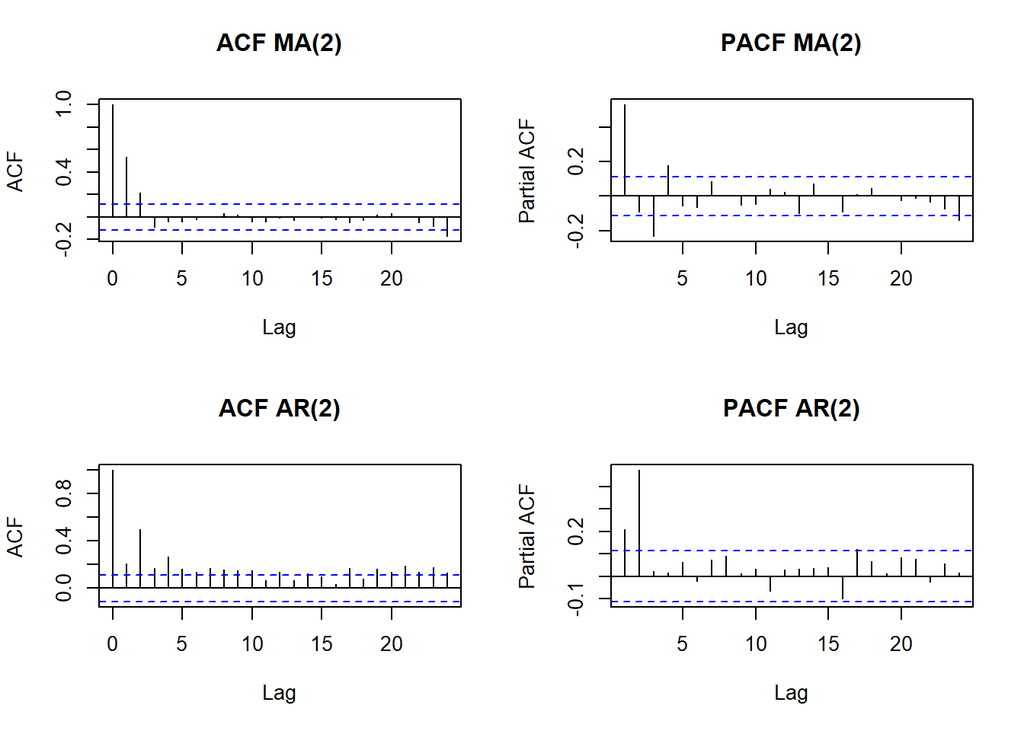

```r
# Bangkitkan data MA(2) dan AR(2)
ma2 <- arma.sim(300, c(0.4, 0.6), 0)    # MA(2)
ar2 <- arma.sim(300, 0, c(0.5, 0.1))     # AR(2)

# Plot ACF dan PACF
par(mfrow = c(2, 2))
acf(ma2, main = "ACF MA(2)")
pacf(ma2, main = "PACF MA(2)")
acf(ar2, main = "ACF AR(2)")
pacf(ar2, main = "PACF AR(2)")
```

```r
# Langkah 3.5:  ARMA(2,2)
phi <- c(0.5, 0.2)       # AR(2)
theta <- c(0.4, 0.6)     # MA(2)

# Bangkitkan data ARMA(2,2) 300 titik
arma22 <- arma.sim(300, macoef = theta, arcoef = phi)

# Fitting ARMA(2,2) ke data hasil simulasi
arma22_model <- arima(arma22, order = c(2,0,2))
arma22_model
```

```
##
## Call:
## arima(x = arma22, order = c(2, 0, 2))
##
## Coefficients:
##          ar1     ar2     ma1     ma2  intercept
##       0.2287  0.4495  0.5824  0.4585    -0.1082
## s.e.  0.0833  0.0818  0.0783  0.0655     0.1807
##
## sigma^2 estimated as 0.2503:  log likelihood = -218.92,  aic = 449.84
```

```r
set.seed(1234)

n <- 300
wn <- rnorm(n, mean = 0, sd = 0.5)   # white noise

# Koefisien ARMA(2,2)
phi <- c(0.5, 0.2)      # AR(2)
theta <- c(0.4, 0.6)    # MA(2)

# Inisialisasi vektor
y.arma <- wn
y.arma[1:2] <- wn[1:2]  # seed awal untuk AR(2)

# Loop manual untuk simulasi ARMA(2,2)
for(i in 3:n){
  y.arma[i] <- phi[1]*y.arma[i-1] + phi[2]*y.arma[i-2] +
               theta[1]*wn[i-1] + theta[2]*wn[i-2] +
               wn[i]
}

y.arma
```

```
##   [1] -0.60353287  0.13871462  0.18423745 -0.75287020 -0.26883245 -0.64984669
##   [7] -0.43611123 -0.58447211 -0.94343266 -1.31050962 -1.42988086 -1.83868546
##  [13] -1.93628095 -1.75841487 -1.00670100 -0.69893977 -0.54052372 -1.00093507
##  [19] -1.36270005 -0.11441241 -0.03068658  0.46799948 -0.05032222  0.06291816
##  [25] -0.36571196 -0.89524202 -0.73114260 -1.37595789 -0.87408105 -1.49033078
##  [31] -0.56056404 -0.87646978 -0.66949707 -1.04523745 -1.78414850 -2.16112748
##  [37] -3.24966516 -3.51384838 -3.47621468 -3.13498252 -1.71945373 -1.87091474
##  [43] -1.48591010 -1.74911524 -1.98164367 -2.10795696 -2.49597120 -2.80758787
##  [49] -2.74749487 -2.66405137 -3.04105872 -2.85463883 -3.24820053 -3.09890974
##  [55] -2.81590903 -2.08315906 -0.71693429 -0.66329543  0.66759480 -0.28859006
##  [61]  0.56772934  1.28461732  1.44524909  1.40247646  0.84213084  1.38769191
##  [67]  0.64610372  1.58990762  1.52094006  1.92294907  1.73527296  1.12681233
##  [73]  0.63817290  0.65864679  1.51179354  1.41946706  0.90714334  0.05151448
##  [79] -0.22560985 -0.42645377 -0.33317713 -0.46755208 -1.07389821 -1.04281171
##  [85] -0.75751737 -0.12060637  0.45778344  0.32268654  0.24155588 -0.57108704
```

[output cut: 35 more lines]

```r
# Langkah 3.7: Pembangkitan ARMA(2,2) dengan arima.sim
set.seed(1234)

arma22 <- arima.sim(list(order = c(2,0,2), ar = c(0.5, 0.2), ma = c(0.4, 0.6)), n = 300)
arma22
```

```
## Time Series:
## Start = 1
## End = 300
## Frequency = 1
##   [1] -2.75189059 -1.74814288 -2.98064692 -1.12111691 -1.75293106 -1.33898765
##   [7] -2.09046996 -3.56829323 -4.32225209 -6.49932813 -7.02769509 -6.95242810
##  [13] -6.26996407 -3.43890672 -3.74182891 -2.97181976 -3.49823015 -3.96328709
##  [19] -4.21591372 -4.99194225 -5.61517562 -5.49498965 -5.32810268 -6.08211738
##  [25] -5.70927763 -6.49640104 -6.19781946 -5.63181804 -4.16631811 -1.43386858
##  [31] -1.32659085  1.33518960 -0.57718012  1.13545868  2.56923465  2.89049818
##  [37]  2.80495292  1.68426168  2.77538382  1.29220743  3.17981524  3.04188012
##  [43]  3.84589813  3.47054592  2.25362466  1.27634579  1.31729358  3.02358708
##  [49]  2.83893413  1.81428668  0.10302896 -0.45121970 -0.85290753 -0.66635425
##  [55] -0.93510416 -2.14779642 -2.08562341 -1.51503473 -0.24121274  0.91556687
##  [61]  0.64537308  0.48311177 -1.14217407 -1.12039092 -1.27141453  0.91636167
```

[output cut: 39 more lines]

## Karakteristik ARMA (2,2)

### Plot Time Series

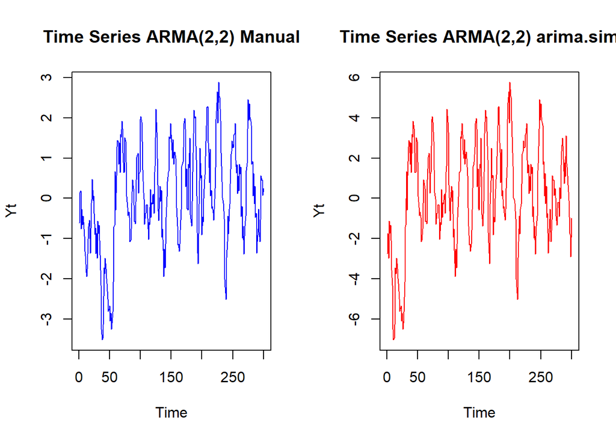

```r
# Plot Time Series ARMA(2,2)
par(mfrow = c(1, 2))

# Simulasi manual dengan loop
ts.plot(y.arma, main = "Time Series ARMA(2,2) Manual", ylab = "Yt", col = "blue")

# Simulasi dengan arima.sim
ts.plot(arma22, main = "Time Series ARMA(2,2) arima.sim", ylab = "Yt", col = "red")
```

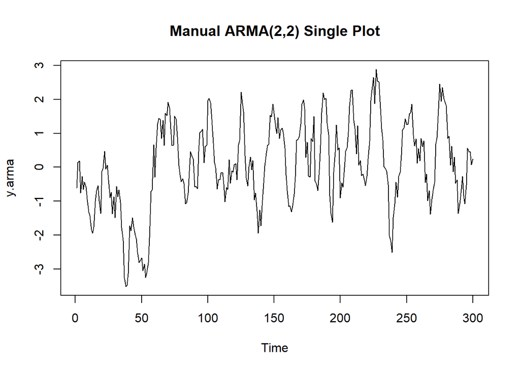

```r
par(mfrow = c(1, 1))  # kembalikan layout ke default
ts.plot(y.arma, main = "Manual ARMA(2,2) Single Plot")
```

Berdasarkan plot time series tersebut, terlihat bahwa model ARMA(2,2) cenderung stasioner dalam rataan